# TP : PILE DYNAMIQUE

# Mode d'emploi du notebook

Durant ce TP, vous aurez à écrire du code C que vous sauvegarderez dans des fichiers ; ces fichiers seront ensuite compilés puis exécutés.

**RAPPEL**

Les fichiers .c, .h et Makefile sont à éditer dans un éditeur de texte, selon votre habitude avec : kate, gedit, nano, vim, ... Vous réalisez la mise au point de votre programme depuis le terminal. Une fois le programme validé, vous recopiez le code dans les cellules dédiées. Vous n'oubliez pas de reporter également les résultats des tests unitaires (avec commentaires associé).

Vous veillerz à la lisibilité du code et à la trace claire des résulttas de test : Ce que vous cherchez à teste + résultat du test obtenu.

# Sujet 2 : PILE DYNAMIQUE

Il s’agit d’implanter la structure de données PILE (LIFO - last in, first out - le dernier entré est le premier sorti) de manière **dynamique**.

Une pile dynamique est représentée par un pointeur vers une cellule qui contient d’une part un élément et d’autre part un pointeur vers la cellule suivante.

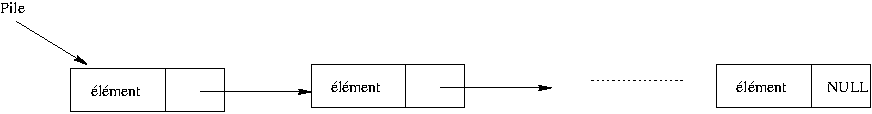

**Attention, votre code doit être modulaire et générique** !! Donc, tout le long de ce TP, il faudra utiliser les mécanismes de compilation séparée permettant de créer vos exécutables à partir de plusieurs fichier sources en utilisant la commande *make* et un fichier *Makefile*.

# Etape 1, sujet 2 : Unité Element

Vous allez réutiliser l'unité *Element* de l'**étape 1 du sujet 1 (TP Pile Statique)**. Donc coller le code de chaque fichier qui constituent l'unité ELEMENT (Element.c, Element.h, tstElement.c), le résultat de la compilation et celui des tests.

**ATTENTION** : vous ne devez faire aucune modification par rapport au code du sujet 1.

# Etape 2, sujet 2 : Unité PileDynamique

- un fichier "header" nommé *PileDynamique.h* qui contiendra la définition du type *PILE* avec l'inclusion du header de l'unité *Element* ainsi que les prototypes des fonctions demandées ci-après
- un fichier "source" nommé *PileDynamique.c* qui contiendra l'instruction *#include "PileDynamique.h"* (inclusion du fichier header) et le code de toutes les fonctions

Pour les tests, vous utiliserez l'unité *Element* définie à l'étape 1 ainsi que le fichier *tstPileDynamique.c* fourni ci-après qui contient l'appel de la fonction *main* permettant de tester toutes les fonctions demandées.

Pour faire la compilation séparée, vous mettrez à jour le fichier *Makefile* défini pour le sujet 1.

Les fonctions demandées sont les suivantes :

- **init_PILE** qui initialise une pile en respectant le prototype : **PILE init_PILE()**.
- **affiche_PILE** qui permet d’afficher tous les éléments d’une pile donnée en paramètre en respectant le prototype : **void affiche_PILE(PILE)**.
- **PILE_estVide** qui permet de tester si une pile donnée en paramètre est vide en respectant le prototype : **int PILE_estVide(PILE)**.
- **emPILE** qui permet d’empiler un élément (donné en paramètre) dans une pile (donnée en paramètre) en respectant le prototype : **PILE emPILE(PILE, Element)**.
- **dePILE* qui permet de depiler une pile (donnée en paramètre), cette fonction doit aussi renvoyer l'élément qui était en tête de pile en respectant le prototype : **PILE dePILE(PILE, Element *)**.
- **saisir_PILE** en respectant le prototype : **PILE saisir_PILE()**. Cette fonction permet de saisir une pile en demandant à l’utilisateur d’entrer les éléments un par un et en les insérant dans la pile.

## Fichier tstPileDynamique.c

/* Fichier tstPileDynamique.c - test de manipulation pour les PILEs dynamiques */ /* Affiche des OK si le test est correct et NOK sinon */ /**********************************************************************************/

# include "PileDynamique.h"

int main() {PILE p ; int e ; int i ;

p = init_PILE() ; printf("OK (1)\n") ;

if (PILE_estVide(p)) printf("OK (2)\n") ; else printf("\t NOK (2)\n") ;

p = emPILE(p,1) ; printf("OK (3)\n") ; if (!PILE_estVide(p)) printf("OK (4)\n") ; else printf("\t NOK (4)\n") ;

p = emPILE(p,2) ; printf("OK (5)\n") ; if (!PILE_estVide(p)) printf("OK (6)\n") ; else printf("\t NOK (6)\n") ;

p = emPILE(p,3) ; printf("OK (7)\n") ; if (!PILE_estVide(p)) printf("OK (8)\n") ; else printf("\t NOK (8)\n") ;

p = dePILE(p,&e) ; printf("OK (9)\n") ; if (e==3) printf("OK (10)\n") ; else printf("\t NOK (10)\n") ; if (!PILE_estVide(p)) printf("OK (11)\n") ; else printf("\t NOK (11)\n") ;

p = dePILE(p,&e) ; printf("OK (12)\n") ; if (e==2) printf("OK (13)\n") ; else printf("\t NOK (13)\n") ; if (!PILE_estVide(p)) printf("OK (14)\n") ; else printf("\t NOK (14)\n") ;

p = dePILE(p,&e) ; printf("OK (15\n") ; if (e==1) printf("OK (16)\n") ; else printf("\t NOK (16)\n") ; if (PILE_estVide(p)) printf("OK (17)\n") ; else printf("\t NOK (17)\n") ;

p = dePILE(p,&e) ; printf("OK (18)\n") ; if (PILE_estVide(p)) printf("OK (19)\n") ; else printf("\t NOK (19)\n") ;

for (i = 0 ; i < 1000; i++) p = emPILE(p,i) ; printf("OK (20)\n") ;

p = emPILE(p,1000) ; printf("OK (21)\n") ;

if (!PILE_estVide(p)) printf("OK (22)\n") ; else printf("\t NOK (22)\n") ;

p = dePILE(p,&e) ; printf("OK (23)\n") ; if (!PILE_estVide(p)) printf("OK (24)\n") ; else printf("\t NOK (24)\n") ; p = emPILE(p,1000) ; printf("OK (25)\n") ;

}

# Etape 3, sujet 2 : Application au train

Vous allez réutiliser, sans la modifier, l'unité **Element** de l'étape 3 du sujet 1.

Vous allez aussi réutiliser l'application définie lors de l'étape 3 du sujet 1.

Le travail à faire :

- Récupérez et exécutez les cellules de code correspondantes à l'unité *Element* de l'**étape 3 du sujet 1**.
- Récupérez, modifiez et tester le fichier **Application.c** de manière à ce que l'application **utilise maintenant une pile dynamique** à la place d'une pile statique.

Pour faire la compilation séparée, vous récupérerez en le mettant à jour le fichier **Makefile** utilisé à l'**étape 2, sujet 2**.

Attention, si vous avez bien fait votre travail, vous ne devriez avoir qu'une **seule modification** à faire dans le fichier **Application.c** avant de reconstruire l'exécutable.